*Source: Olga Lyashevskaya, George Moroz, Alla Tambovtseva, and Ilya Schurov. Linguistic Data: Quantitative Analysis and Visualisation. The HSE course taught in MA programs in linguistics since 2015.*

Домашнее задание сдается в виде двух файлов, Rmd и html (или в виде тетрадки, если вы выполняли задание в колабе). Чтобы облегчить проверку домашнего задания, мы просим вас писать код в блоки для кода на R, например,

```r
# YOUR CODE HERE
# (do not forget to remove #'s and all this text so that we could run the code)
```

и текст в блоки для текста. Пожалуйста, впишите ниже ваше имя и фамилию:

```
     Артамонова Ксения
```

Перед сдачей домашнего задания рекомендуем запустить `Run All` или сгенерировать html-страницу с помощью `Knit`, чтобы убедиться, что в финальной версии весь ваш код будет запускаться без проблем. Дисклеймер - в зависимости от среды, в которой вы выполняете задания, округление непрерывных значений может производиться несколько по-разному. В заданиях ниже не будут оцениваться расхождения с образцом в количестве знаков после запятой в выдаче. Аналогично, несколько иначе могут выглядеть шрифты в таблицах и графиках, на такие расхождения тоже не стоит обращать внимания, если нет специального требования в задании. И не стесняйтесь задавать вопросы по домашнему заданию в телеграм-группе.

## 1. Частотность и фонетика

(первая часть домашнего задания строится на тех же данных, что были в предыдущем домашнем задании)

Во многих лингвистических исследованиях отмечается, что часто используемые в языке слова звучат короче, а при их произнесении наблюдается редукция и коартикуляция. Работа [Fabian Tomaschek et al.](https://www.semanticscholar.org/paper/Practice-makes-perfect-%3A-The-consequences-of-for-Tomaschek-Tucker/1e0dbc3787a6da84ffd4c3cae62f1340e4267694) (2018) исследует гипотезу, что моторные навыки произнесения улучшаются с опытом, который, в свою очередь, напрямую связан с частотностью слова. Ученые попросили испытуемых (17 бакалавров университета Тюбингена, 8 мужчин и 9 женщин) прочитать вслух немецкие глаголы, содержащие звук [a:] в основе. Испытуемые были поставлены в экспериментальные условия, которые исподволь заставляли их читать быстрее или медленнее (slow/fast condition).

В этом задании мы просим вас сравнить длину звучания всего слова целиком, а также длину звучания интересующего ученых сегмента (звука [a:]) в условиях slow и fast. Хотя логично предположить, что в условии fast произнесение и слов, и сегментов будет короче, все же нужно убедиться, что данные это подтверждают, прежде чем переходить к более сложному анализу по сути вопроса. Кроме того, мы будем уверены, что экспериментальные условия были должным образом соблюдены, ученые не запутались в кодировании данных и документировали результаты корректно.

**Интересующие нас переменные:**

- `LogDurationW` - log-transformed word duration (логарифм длины произнесения слова)
- `LogDurationA` - log-transformed segment duration (логарифм длины произнесения сегмента)
- `Cond` - condition: slow vs. fast (условие).

### 1.0 Загрузка данных

Загрузим пакет `tidyverse`, а данные загрузим в переменную `dur_word_freq`.

```r
library(tidyverse)
dur_word_freq <- read_csv("https://raw.githubusercontent.com/LingData2019/LingData2020/master/data/dur_word_frequency.csv")
```

### 1.1 Исследуем набор данных

Выведите все уникальные значения, которые встречаются в столбце `Lemma`, с помощью функции `distinct()`, см. фрагмент ниже:

| Lemma |
| --- |
| <chr> |
| schab |
| blas |
| schlaf |
| … |

```r
dur_word_freq %>%
  distinct(Lemma)
```

```
## # A tibble: 17 × 1
##    Lemma
##    <chr>
##  1 schab
##  2 blas
##  3 schlaf
##  4 lahm
##  5 fahnd
##  6 mahn
##  7 bahn
##  8 schad
##  9 wat
## 10 tafeln
## 11 latsch
## 12 zahn
## 13 faseln
## 14 tadeln
## 15 bad
## 16 zahl
## 17 stapeln
```

### 1.2 Пропущенные значения

Давайте убедимся, что наши данные не содержат значений NA (а если содержат, то хорошо бы знать, в каких столбцах). Используйте функции `map_int()` и `is.na()`, чтобы сделать выдачу, которая позволит исследовать вопрос.

```r
dur_word_freq %>%
  map_int(~ sum(is.na(.)))
```

```
##         ...1 LogDurationA LogDurationW        Lemma  Participant         Cond
##            0            0            0            0            0            0
##     Exponent    Frequency
##            0            0
```

### 1.3 Данные как факторы

Факторы - это строковые переменные, закодированные числами (как levels) для экономии вычислительных ресурсов. Некоторые функции в R работают только с факторами, а некоторые методы чувствительны к порядку кодирования, поэтому перевод из строк в факторы иногда бывает полезен. Используя функции `mutate()` и `across()`, переведите все строковые переменные в столбцах в факторы, а затем посмотрите на структуру тиббла с помощью функции `str()`.

```r
dur_word_freq <- dur_word_freq %>%
  mutate(across(where(is.character), as.factor))
str(dur_word_freq)
```

```
## tibble [832 × 8] (S3: tbl_df/tbl/data.frame)
##  $ ...1        : num [1:832] 11431 1 136 71 11581 ...
##  $ LogDurationA: num [1:832] -1.32 -1.36 -1.5 -1.28 -1.33 ...
##  $ LogDurationW: num [1:832] -0.477 -0.36 -0.27 -0.377 -0.447 ...
##  $ Lemma       : Factor w/ 17 levels "bad","bahn","blas",..: 9 3 11 6 6 4 8 2 10 15 ...
##  $ Participant : Factor w/ 17 levels "Art_02_S01","Art_02_S03",..: 1 1 1 1 1 1 1 1 1 1 ...
##  $ Cond        : Factor w/ 2 levels "fast","slow": 2 2 2 2 2 2 2 2 2 2 ...
##  $ Exponent    : Factor w/ 3 levels "en","n","t": 3 2 1 1 3 1 1 3 2 2 ...
##  $ Frequency   : num [1:832] -6.98 -5.74 -4.68 -6.26 -6.47 ...
```

### 1.4 Кодирование факторов

Догадайтесь, вспомните или прочитайте, по какому принципу кодируются факторы по умолчанию (подсказка: в переменной `Cond` значение `fast` имеет уровень 1, а `slow` имеет уровень 2).

```
    Они кодируются в алфавитном порядке
```

### 1.5 Усредненные длительности сегмента и слова

Сгруппировав данные по условию (`Cond`), выведите средние значения лог-трансформированных длин сегмента и слова примерно в таком виде (названия столбцов должны совпадать с данными в примере, округление числовых переменных может отличаться):

| Cond | meanLogDurA | meanLogDurW |
| --- | --- | --- |
| <chr> | <dbl> | <dbl> |
| fast | -1.738072 | -0.5836253 |
| slow | -1.628756 | -0.4483053 |

```r
dur_word_freq %>%
  group_by(Cond) %>%
  summarise(
    meanLogDurA = mean(LogDurationA),
    meanLogDurW = mean(LogDurationW)
  )
```

```
## # A tibble: 2 × 3
##   Cond  meanLogDurA meanLogDurW
##   <fct>       <dbl>       <dbl>
## 1 fast        -1.74      -0.584
## 2 slow        -1.63      -0.448
```

### 1.6 Больше описательных статистик для длительности сегмента и слова

Добавьте в таблицу 1.4 минимальные, максимальные и медианные значения для групп fast и slow (названия столбцов могут быть другими, чем в 1.4). Вам могут быть полезны функции `min()`, `max()` и `median()`.

```r
dur_word_freq %>%
  group_by(Cond) %>%
  summarise(
    meanLogDurA = mean(LogDurationA),
    minLogDurA = min(LogDurationA),
    maxLogDurA = max(LogDurationA),
    medianLogDurA = median(LogDurationA),
    meanLogDurW = mean(LogDurationW),
    minLogDurW = min(LogDurationW),
    maxLogDurW = max(LogDurationW),
    medianLogDurW = median(LogDurationW)
  )
```

```
## # A tibble: 2 × 9
##   Cond  meanLogDurA minLogDurA maxLogDurA medianLogDurA meanLogDurW minLogDurW
##   <fct>       <dbl>      <dbl>      <dbl>         <dbl>       <dbl>      <dbl>
## 1 fast        -1.74      -2.57      -1.23         -1.72      -0.584      -1.17
## 2 slow        -1.63      -3.51      -1.10         -1.64      -0.448      -1.24
## # ℹ 2 more variables: maxLogDurW <dbl>, medianLogDurW <dbl>
```

### 1.7 Длинный и короткий формат

Данные в наборе, с которым мы работаем, следуют “длинному” формату - каждой точке наблюдения соответствует своя строка. Отфильтруйте данные по условию “slow” и по значению “t” переменной `Exponent` (окончание глагольной формы), затем представьте их в широком формате таким образом, чтобы каждая строка представляла длительность произнесения разных слов одним испытуемым (см. фрагмент ниже).

| Participant | schab | lahm | bahn |
| --- | --- | --- | --- |
| <chr> | <dbl> | <dbl> | <dbl> |
| Art_02_S01 | -0.4768593 | -0.4471271 | -0.4085488 |
| Art_02_S03 | -0.4780197 | -0.5621014 | -0.5621014 |
| Art_02_S04 | -0.5798006 | -0.7550013 | -0.7133295 |

```r
filtered_data <- dur_word_freq %>%
  filter(Cond == "slow", Exponent == "t") %>%
  select(Participant, Lemma, LogDurationW)

wide_data <- filtered_data %>%
  pivot_wider(
    names_from = Lemma,
    values_from = LogDurationW
  )

wide_data
```

```
## # A tibble: 17 × 10
##    Participant  schab   lahm   bahn   zahn latsch   zahl   blas   mahn schlaf
##    <fct>        <dbl>  <dbl>  <dbl>  <dbl>  <dbl>  <dbl>  <dbl>  <dbl>  <dbl>
##  1 Art_02_S01  -0.477 -0.447 -0.409 -0.462 -0.223 -0.511 -0.416 -0.580 -0.431
##  2 Art_02_S03  -0.478 -0.562 -0.562 -0.616 -0.693 -0.528 -0.528 -0.616 -1.24
##  3 Art_02_S04  -0.580 -0.755 -0.713 -0.580 -0.616 -0.598 -0.545 -0.713 -0.545
##  4 Art_02_S05  -0.654 -0.713 -0.478 -0.635 -0.266 -0.431 -0.654 -0.734 -0.734
##  5 Art_02_S08  -0.462 -0.673 -0.616 -0.301 -0.494 -0.416 -0.357 -0.598 -0.248
##  6 Art_02_S09  -0.545 -0.892 -0.400 -0.446 -0.635 -0.777 -0.446 -0.942 -0.315
##  7 Art_02_S10  -0.528 -0.693 -0.562 -0.693 -0.616 -0.616 -0.511 -0.528 -0.511
##  8 Art_02_S12  -0.755 -0.511 -0.511 -0.357 -0.528 -0.580 -0.635 -0.580 -0.223
##  9 Art_02_S15  -0.400 -0.545 -0.545 -0.446 -0.545 -0.673 -0.446 -0.713 -0.462
## 10 Art_02_S16  -0.580 -0.616 -0.528 -0.494 -0.211 -0.357 -0.511 -0.511 -0.386
## 11 Art_02_S17  -0.598 -0.738 -0.654 -0.654 -0.371 -0.616 -0.603 -0.734 -0.528
## 12 Art_02_S18  -0.301 -0.163 -0.386 -0.211 -0.462 -0.261 -0.198 -0.431 -0.261
## 13 Art_02_S20  -0.528 -0.654 -0.494 -0.400 -0.163 -0.431 -0.755 -0.673 -0.416
## 14 Art_02_S21  -0.713 -0.892 -0.528 -0.528 -0.635 -0.562 -0.462 -0.673 NA
## 15 Art_02_S22  -0.511 -0.431 -0.528 -0.462 -0.236 NA     -0.462 -0.357 -0.400
## 16 Art_02_S23  -0.598 -0.654 -0.673 -0.511 NA     -0.545 -0.416 -0.755 NA
## 17 Art_02_S24  -0.105 -0.635 -0.462 -0.386 -0.248  0.519  0.464 -0.301 -0.236
```

### 1.8

Найдите глагол, для которого в заданных экспериментальных условиях нет данных минимум по двум испытуемым.

```
schlaf
```

### 1.9

Ваш код для этого задания:

```r
missing_counts <- wide_data %>%
  summarise(across(-Participant, ~ sum(is.na(.)))) %>%
  pivot_longer(everything(), names_to = "Lemma", values_to = "missing_count") %>%
  filter(missing_count >= 2)

missing_counts
```

```
## # A tibble: 1 × 2
##   Lemma  missing_count
##   <chr>          <int>
## 1 schlaf             2
```

### 1.10

Сколько примерно времени вы потратили на выполнение первой части домашнего задания? (Округлите до получаса, считая чистое время без отвлечения на другие дела).

```
     30 минут
```

## 2. Лингвистические интересы студентов

(предыдущая часть домашнего задания позволяет получить максимум 7 баллов. Сделав это задание, вы сможете повысить оценку).

В файле по ссылке ниже приведены ответы студентов в опроснике по курсу.

- ID – id студента (данные анонимизированы)
- Topics – ответ студента на вопрос, какие области теоретической лингвистики его интересуют.

Гугл-форма превращает несколько выбранных ответов в строку, где темы разделены запятой. В датасете данные представлены в таком виде: `"грамматика и семантика", "социолингвистика"`.

```r
topics <- read_tsv("https://raw.githubusercontent.com/olesar/2026davR-hse-CL/refs/heads/main/data/students2026_topics.tsv")
```

### 2.1

Используя функцию `separate_rows()`, представьте данные примерно в таком виде (порядок столбцов может быть любым):

| ID | фонетика и интонация | история языка | компаративистика | … |
| --- | --- | --- | --- | --- |
| <dbl> | <lgl> | <lgl> | <lgl> | … |
| 1 | TRUE | TRUE | TRUE | … |
| 2 | FALSE | FALSE | TRUE | … |
| 3 | FALSE | TRUE | TRUE | … |

Ваш код для этого задания:

```r
topics_wide <- topics %>%
  separate_rows(Topics, sep = ",\\s*") %>%
  mutate(Topics = str_remove_all(Topics, '"') %>% str_trim()) %>%
  mutate(present = TRUE) %>%
  pivot_wider(
    id_cols = ID,
    names_from = Topics,
    values_from = present,
    values_fill = FALSE
  )
topics_wide
```

```
## # A tibble: 59 × 18
##       ID `грамматика и семантика` лингвогеография экспериментальная лингвистик…¹
##    <dbl> <lgl>                    <lgl>           <lgl>
##  1     1 TRUE                     TRUE            TRUE
##  2     2 TRUE                     FALSE           TRUE
##  3     3 FALSE                    FALSE           FALSE
##  4     4 TRUE                     TRUE            FALSE
##  5     5 FALSE                    FALSE           TRUE
##  6     6 TRUE                     FALSE           FALSE
##  7     7 TRUE                     FALSE           TRUE
##  8     8 FALSE                    TRUE            TRUE
##  9     9 TRUE                     FALSE           FALSE
## 10    10 FALSE                    FALSE           TRUE
## # ℹ 49 more rows
## # ℹ abbreviated name: ¹`экспериментальная лингвистика - любые темы`
## # ℹ 14 more variables:
## #   `изучаемые с помощью психо- и нейролингвистических методов` <lgl>,
## #   `фонетика и интонация` <lgl>, социолингвистика <lgl>,
## #   `история языка` <lgl>, компаративистика <lgl>, филогенетика <lgl>,
## #   `анализ данных в литературоведении` <lgl>, …
```

### 2.2

Добавьте в код еще одну строку, чтобы с помощью функций `summarise`, `across` и `where` получить тиббл, в котором подсчитано количество значений TRUE по каждому столбцу. Пример:

| фонетика и интонация | история языка | компаративистика | … |
| --- | --- | --- | --- |
| <int> | <int> | <int> | … |
| 7 | 4 | 4 | … |

Подсказки:  
1) есть функция, которая позволяет узнать, принадлежат ли данные к типу логических данных.  
2) TRUE + TRUE + FALSE = 2

Ваш код для этого задания:

```r
topics_noid <- topics %>%
  separate_rows(Topics, sep = ",\\s*") %>%
  mutate(Topics = str_remove_all(Topics, '"') %>% str_trim()) %>%
  mutate(present = TRUE) %>%
  pivot_wider(
    id_cols = ID,
    names_from = Topics,
    values_from = present,
    values_fill = FALSE
  ) %>%
  select(-ID) %>%
  summarise(across(everything(), ~ sum(.)))
topics_noid
```

```
## # A tibble: 1 × 17
##   `грамматика и семантика` лингвогеография экспериментальная лингвистика - люб…¹
##                      <int>           <int>                                 <int>
## 1                       32               7                                    35
## # ℹ abbreviated name: ¹`экспериментальная лингвистика - любые темы`
## # ℹ 14 more variables:
## #   `изучаемые с помощью психо- и нейролингвистических методов` <int>,
## #   `фонетика и интонация` <int>, социолингвистика <int>,
## #   `история языка` <int>, компаративистика <int>, филогенетика <int>,
## #   `анализ данных в литературоведении` <int>,
## #   `истории и других гуманитарных науках` <int>, …
```

### 2.3 Визуализация

С помощью ggplot2 визуализируйте полученные частоты упоминаний областей лингвистики в виде столбчатой диаграммы, у вас должна получиться похожая столбчатая диаграмма, но с другими значениями:

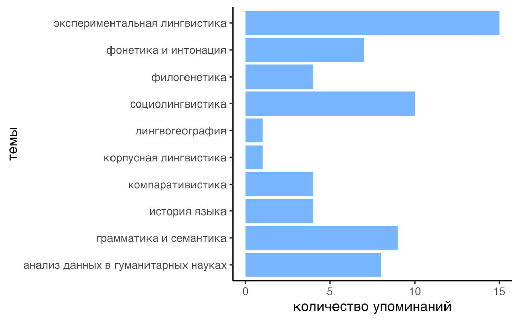

1. Во-первых, решим проблему того, что ggplot не сможет легко извлечь данные, записанные в отдельных столбцах. Код ниже показывает, как с помощью `pivot_longer()` можно транспонировать их в такой формат, чтобы `ggplot` мог пользоваться векторами, заданными в двух столбцах - названиями областей в одном `topics` и счетчиком в другом (`counts`). (Здесь полученные ранее данные сохранены в переменную `topic_counts`).

```r
topic_counts |>
  pivot_longer(cols=everything(), names_to = "topics", values_to = "counts")
```

2. Во-вторых, отфильтруйте строку, в которой встретилась тема “NA” - дело в том, что один из студентов не захотел отвечать на этот вопрос.
3. В-третьих, отфильтруйте те ответы, которые не являются собственно наименованиями областей лингвистики (некоторые студенты добавили комментарии в вольном стиле). Есть несколько способов, как это сделать, достаточно использовать один.
4. Теперь используйте геом `geom_col` c заливкой столбцов цветом `#77b6ff` и классической темой, чтобы получить столбчатую диаграмму. Обратите внимание, что нужно горизонтально расположить столбцы для лучшей читаемости длинных подписей.

Ваш код для этого задания:

```r
topics_long <- topics_wide %>%
  select(-ID) %>%
  summarise(across(everything(), ~ sum(.))) %>%
  pivot_longer(
    cols = everything(),
    names_to = "topics",
    values_to = "counts"
  ) %>%
  filter(!is.na(topics), topics != "", topics != "NA") %>%
  filter(!str_detect(topics, "грамматика и семантика|лингвогеография|экспериментальная лингвистика|изучаемые с помощью психо- и нейролингвистических методов
фонетика и интонация|фонетика и интонация|социолингвистика|история языка|компаративистика|филогенетика|анализ данных в литературоведении, истории и других гуманитарных науках|корпусная лингвистика", negate = TRUE)) %>%
  arrange(desc(counts))
topics_long
```

```
## # A tibble: 9 × 2
##   topics                                     counts
##   <chr>                                       <int>
## 1 экспериментальная лингвистика - любые темы     35
## 2 грамматика и семантика                         32
## 3 социолингвистика                               28
## 4 фонетика и интонация                           21
## 5 история языка                                  13
## 6 компаративистика                               13
## 7 филогенетика                                   13
## 8 лингвогеография                                 7
## 9 корпусная лингвистика                           1
```

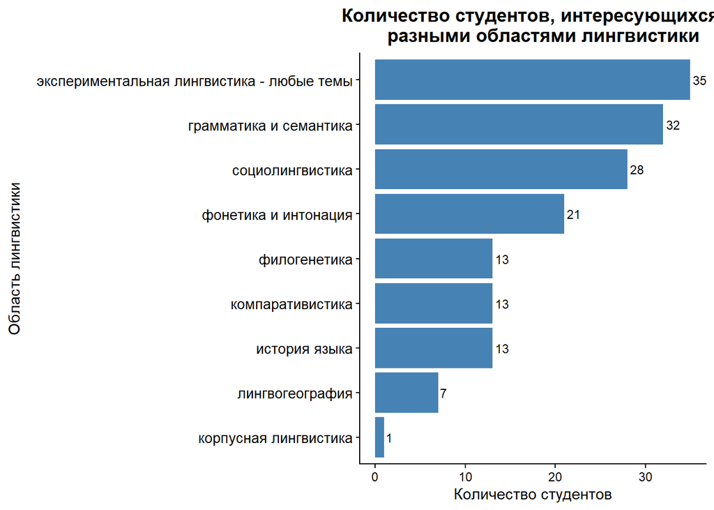

```r
ggplot(topics_long, aes(x = reorder(topics, counts), y = counts)) +
  geom_col(fill = "steelblue") +
  geom_text(aes(label = counts), hjust = -0.2, size = 3) +
  coord_flip() +
  labs(
    title = "Количество студентов, интересующихся
    разными областями лингвистики",
    x = "Область лингвистики",
    y = "Количество студентов"
  ) +
  theme_classic() +
  theme(
    plot.title = element_text(hjust = 0.5, face = "bold"),
    axis.text.y = element_text(size = 10),
    axis.title.y = element_text(margin = margin(r = 10))
  )
```

### 3.1 Адрес репозитория на github

Вы можете выкладывать задания, которые делаете самостоятельно на семинаре, в репозиторий на гитхабе. Если вы хотите получать фидбек, укажите адрес этого репозитория ниже:

```
https://github.com/blankqspace/data_analysis_R_homeworks
```

### 3.2

Это необязательно, но вы можете написать здесь свои комментарии по домашнему заданию, если хотите.

[output not shown]

### Полезное

В сети есть много шпаргалок по работе с датафреймами, например:

- [https://rstudio.github.io/cheatsheets/tidyr.pdf]
- [https://rstudio.github.io/cheatsheets/html/tidyr.html]

Шпаргалки для ggplot:

- [https://rstudio.github.io/cheatsheets/data-visualization.pdf]
- [https://rstudio.github.io/cheatsheets/html/data-visualization.html]